# Hochschule Bonn-Rhein-Sieg

# Mathematics for Robotics and Control, SS17

# Assignment 1 - Frames

This week's assignment is about frames of reference. As you have learned in the lecture, the concept of frames is of great importance in robotics.

Let us consider a mobile robot (e.g. a youBot) that delivers packages in a lab. The robot is equipped with several sensors, including a camera for perceiving its environment and a gripper for grasping objects. You will use your knowledge of frames to help our robot complete its tasks.

Let us first setup this notebook so that figures and plots can be shown in the notebook page. Once you run the following cell, you don't have to import any of the packages in the subsequent code cells, as they will be available to all of them.

```python
import numpy as np
import numpy.linalg as linalg
import matplotlib.pyplot as plt

from IPython.core.pylabtools import figsize, getfigs
np.set_printoptions(suppress=True)
```

**Hint**: You might want to check the the NumPy manual [1] before you start. In particular, read and understand the following functions:

```
array()
asarray()
sin()
cos()
tan()
radians()
hstack()
vstack()
dot()
delete()
linalg.inv()
linalg.det()
```

[1] http://docs.scipy.org/doc/numpy/genindex.html

## Picking up a package for the lab

The robot's task for today is to go to the reception and pick up a package that is lying on a cabinet. To do so, the robot has to complete a few subtasks.

### Locate the pose of the reception's door relative to the robot's base frame

Assume that our robot is located in a hallway that leads to the reception. In order to go inside the reception, the robot needs to know the pose of the door $\{D\}$ relative to the base frame $\{B \}$, i.e. we need the transform ${}^{B}_DT$; however, we are given the pose of the door relative to the camera's frame $\{C\}$, as we are using a camera for detecting the reception's door.

With respect to the camera, the door frame $\{D\}$ is rotated $-13.215^o$ about $Z$ and $-28.647^o$ about $Y$ (this a rotation about $Z$ first, followed by a rotation in $Y$ using the *Z-Y-X*-Euler-angle convention) and has a relative translation of $(1.533, -0.354, 0.197)$ meters in $X,Y$, and $Z$ respectively. We also know the pose of the camera relative to the base, $^{B}_CT$: $\{C\}$ is located $(-0.176, 0.035, 0.563)$ meters away from the base frame and is rotated $28.647^o$ about $\{B\}$'s $Y$ axis.

Observe the following figure for a visual description of the frames. The $X$ axis is represented by the red line, the $Y$ axis by the green line, and the $Z$ axis by the blue line.

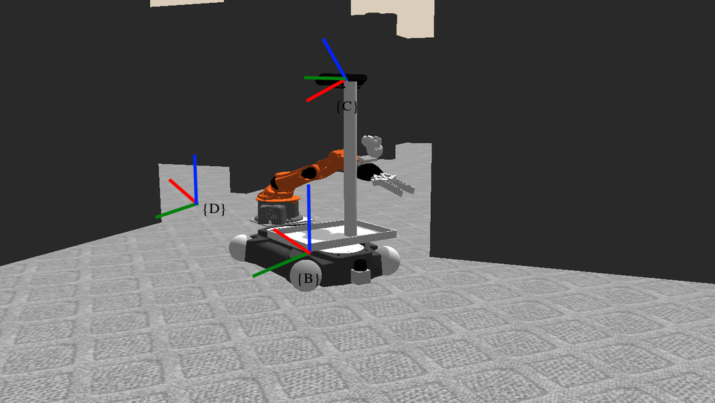

```python
import IPython
IPython.core.display.Image("images/youbot_and_door.png", embed=True)
```

Calculate $^{B}_DT$ by completing the following function.

```python
def get_rotation_matrix_z_axis(theta):
    A_B_R = np.array([[np.cos(theta), -np.sin(theta), 0.],
                      [np.sin(theta), np.cos(theta),  0.],
                      [0.,            0.,             1.]])
    return A_B_R

def get_rotation_matrix_x_axis(theta):
    A_B_R = np.array([[1., 0.,             0.],
                      [0., np.cos(theta), -np.sin(theta)],
                      [0., np.sin(theta), np.cos(theta)]])
    return A_B_R

def get_rotation_matrix_y_axis(theta):
    A_B_R = np.array([[np.cos(theta),  0., np.sin(theta)],
                      [0.,             1., 0.],
                      [-np.sin(theta), 0., np.cos(theta)]])
    return A_B_R

def direct_transform(Rzyx, t):

    """
    This function returns a homogenous transformation describing
    """

    #transposing the translate vector to get a column vector
    t = t[np.newaxis].T

    # stacking translation horizontally
    T = np.hstack((Rzyx, t))

    # stacking  vertically
    T = np.vstack((T, np.array([0., 0., 0., 1])))

    return T


print""
print""
print "Step 1"
print "homogeneous transformation of {D} with respect to {C}"
print "------------------------------------------------------"

C_D_theta_z=np.deg2rad(-13.215)
C_D_theta_y=np.deg2rad(-28.647)

#rotation matrix {D} with respect to {C}
C_D_Rz = get_rotation_matrix_z_axis(C_D_theta_z) #rotaion of frame D with reference to C about Z-axis
C_D_Ry = get_rotation_matrix_y_axis(C_D_theta_y) #rotaion of frame D with reference to C about Y-axis

C_D_Rzyx = np.dot(C_D_Rz,C_D_Ry) #final rotaion of frame D with reference to C

# translation vector
C_D_t = np.array([1.533, -0.354, 0.197])

#homogeneous transformation of {D} with respect to {C}
C_D_T=direct_transform(C_D_Rzyx, C_D_t)

print C_D_T


print""
print""
print "Step 2"
print "homogeneous transformation of {C} with respect to {B}"
print "------------------------------------------------------"

B_C_theta_y=np.deg2rad(28.647)

#rotation matrix {C} with respect to {B}
B_C_Ry = get_rotation_matrix_y_axis(B_C_theta_y) #rotaion of frame C with reference to B about Y-axis

# translation vector
B_C_t = np.array([-0.176,0.035,0.563])

#homogeneous transformation of {D} with respect to {C}
B_C_T=direct_transform(B_C_Ry, B_C_t)

print B_C_T

print""
print""
print "Step 3"
print "homogeneous transformation of {D} with respect to {B}"
print "------------------------------------------------------"


B_D_T= np.dot(B_C_T,C_D_T)
print B_D_T
```

```
Step 1
homogeneous transformation of {D} with respect to {C}
------------------------------------------------------
[[ 0.85435062  0.22860574 -0.46671665  1.533     ]
 [-0.20062212  0.97351909  0.10959632 -0.354     ]
 [ 0.47941191  0.          0.87759001  0.197     ]
 [ 0.          0.          0.          1.        ]]


Step 2
homogeneous transformation of {C} with respect to {B}
------------------------------------------------------
[[ 0.87759001  0.          0.47941191 -0.176     ]
 [ 0.          1.          0.          0.035     ]
 [-0.47941191  0.          0.87759001  0.563     ]
 [ 0.          0.          0.          1.        ]]


Step 3
homogeneous transformation of {D} with respect to {B}
------------------------------------------------------
[[ 0.97960535  0.20062212  0.01114124  1.26378963]
 [-0.20062212  0.97351909  0.10959632 -0.319     ]
 [ 0.01114124 -0.10959632  0.99391374  0.00094677]
 [ 0.          0.          0.          1.        ]]
```

### Reaching for a package

Once the robot has successfully entered the reception and approached the cabinet where the package is, it uses an object detection and recognition module for finding the package relative to the camera frame $\{C \}$. The module reports that, relative to frame $\{C\}$, the package is located at $(1.124, -0.060, 0.473)$ meters in $X, Y$, and $Z$, respectively, and is rotated by $-28.647^o$ about $Y$. This information corresponds to the transform ${}^C_PT$.

From the previous subtask, we know the location of the camera relative to the robot's base (given by ${}^B_CT$). Furthermore, using the robot's kinematics, we can calculate ${}^B_ET$, the transform describing the frame of the manipulator's end-effector $\{E\}$ relative to the base frame $\{B\}$; this is given by a translation of $(0.679, -0.019, 0.445)$ meters in $X, Y$, and $Z$ respectively and a rotation of $90^o$ about $Y$.

For picking up this package, the robot needs to know the package's position and orientation with respect to its end-effector. Your task is to calculate the pose of the package relative to the manipulator's end-effector, namely compute ${}^E_PT$. The following figure shows a description of the frames involved.

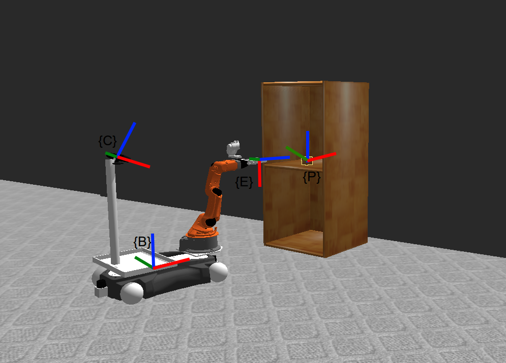

```python
IPython.core.display.Image("images/youbot_and_package.png", embed=True)
```

Calculate $^{E}_PT$ by completing the following function.

````````````````````````````````````````````````````````````python
def inverse_transform(Rzyx, t):
    """
    This function returns a homogenous transformation describing
    the pose of frame {P} relative to frame {E}.

    """
    Rzyx_T = Rzyx.T #Transpose of B_E_Ry

    #transposing the translate vector to get a column vector
    t = t[np.newaxis].T

    t=np.dot(-Rzyx_T,t)

    # stacking translation horizontally
    T = np.hstack((Rzyx_T, t))

    # stacking  vertically
    T = np.vstack((T, np.array([0., 0., 0., 1])))

    return T

print""
print""
print "homogeneous transformation of {P} with respect to {C}"
print "------------------------------------------------------"

C_P_theta_y=np.deg2rad(-28.647)

#rotation matrix {P} with respect to {C}
C_P_Ry = get_rotation_matrix_y_axis(C_P_theta_y) #rotaion of frame P with reference to C about Y-axis

# translation vector
C_P_t = np.array([1.124,-0.060,0.473])

#homogeneous transformation of {P} with respect to {C}
C_P_T=direct_transform(C_P_Ry, C_P_t)

print C_P_T


print""
print""
print "homogeneous transformation of {C} with respect to {B}"
print "------------------------------------------------------"

print B_C_T

print""
print""
print "homogeneous transformation of {E} with respect to {B}"
print "------------------------------------------------------"

B_E_theta_y=np.deg2rad(90)

#rotation matrix {E} with respect to {B}
B_E_Ry = get_rotation_matrix_y_axis(B_E_theta_y) #rotaion of frame P with reference to C about Y-axis

#translation vector
B_E_t = np.array([0.679,-0.019,0.445])

#homogeneous transformation of {E} with respect to {B}
B_E_T=direct_transform(B_E_Ry, B_E_t)

print B_E_T

print""
print""
print "homogeneous transformation of {B} with respect to {E}"
print "------------------------------------------------------"

#homogeneous transformation of {E} with respect to {B}
E_B_T=inverse_transform(B_E_Ry, B_E_t)

print E_B_T

'''
print ""
print ""
print"*******************************************************************************"
print"OR, the same transform can be found by directly taking an inverse of B_E_T"
print"*******************************************************************************"
print "homogeneous transformation of {B} with respect to {E}--II"
print "------------------------------------------------------"

E_B_T= linalg.inv(B_E_T)
print E_B_T
'''
print""
print""
print"```````````````````````````````````````````````````````````"
print"```````````````````````````````````````````````````````````"
print"Finally,"
print "homogeneous transformation of {P} with respect to {E}"
print "------------------------------------------------------"

E_P_T=np.dot(E_B_T,B_C_T,C_P_T)

print E_P_T
````````````````````````````````````````````````````````````

[output not shown]